# community_phenology

Jannet Vu

10/26/2022

Manuscript title: Temperature and rainfall seasonality drives tropical community phenology in southeastern Madagascar

**Goal is to characterize the reproductive phenological cycle (flower and fruit) of plants in Kianjavato at the individual and species level at the monthly scale**  
1) identify the dominant cycle flowering and fruiting frequency (continuous, sub-annual, annual, supra-annual)  
2) calculate the flowering and fruiting cycle length, duration and interval  
3) assess the regularity of flowering and fruiting

#### Set up working environment

First set up working environment and load in relevant files

```r
#load in packages
library(dplyr)
library(lubridate)
library(ggplot2)
library(reshape)
library(doParallel)
library(gridExtra)
library(cowplot)
library(chisq.posthoc.test)
library(DescTools)
library(ggh4x)

# detect cores for parallel computing
numcores <- detectCores() -1
registerDoParallel(numcores) # register cores

# list of month labels
mthname <- c("Jan","Feb","Mar","Apr","May","Jun","Jul","Aug","Sep","Oct","Nov","Dec")

# load appropriate files
# data for plant vernacular and Latin names
plant_names <- read.csv('phen_plantnames.csv', header= T, stringsAsFactors = F) # local plant and Latin names

# data for characterizing individual fruiting cycles
kphen_fr <- read.csv('kian_phen_individual_fruit.csv', header =T, stringsAsFactors = F)[,-1]
kphen_fr$Date <- as.Date(kphen_fr$Date, tz = 'Africa/Nairobi')

# data for characterizing individual flowering cycles
kphen_fl <- read.csv('kian_phen_individual_flower.csv', header = T, stringsAsFactors = F)[,-1]
kphen_fl$Date <- as.Date(kphen_fl$Date, tz = 'Africa/Nairobi')
```

columns:  
species - vernacular name  
year - year  
month - month  
dataset - forest identifier (sssw - sangasanga, vvvw - vatovavy)  
Tag - individual identifier  
Plot- survey plot  
Fu - unripe fruit phenology (0-4)  
Fr - ripe fruit phenology (0-4)  
FuFr - fruit phenology (0-4)  
Fl - flower phenology (0-4)  
fruit - absence/presence of fruit  
flower - absence/presence of flower  
Date - date monthname - categorical month name Latin - scientific name(s)  
multispecies - indicates the taxonomic ambiguity, FALSE = single species, TRUE = multiple species, AMB - single species, but uncertain which species

```r
head(kphen_fr) # visualize to get sense of data
```

```
##   species year month dataset Tag Plot FuFr Fl fruit flower       Date monthname
## 1  Ambora 2018     3    vvsw 395    5  0.0  0     0      0 2018-03-01       Mar
## 2  Ambora 2015     1    sssw 174   13  0.0  1     0      1 2015-01-01       Jan
## 3  Ambora 2013     4    sssw 226   16  0.0  0     0      0 2013-04-01       Apr
## 4  Ambora 2014    12    sssw 174   13  2.0  0     1      0 2014-12-01       Dec
## 5  Ambora 2014    11    sssw 174   13  1.5  0     1      0 2014-11-01       Nov
## 6  Ambora 2018     2    vvsw 395    5  0.0  0     0      0 2018-02-01       Feb
##                     Latin multispecies
## 1 Tambourissa thouvenotii        FALSE
## 2 Tambourissa thouvenotii        FALSE
## 3 Tambourissa thouvenotii        FALSE
## 4 Tambourissa thouvenotii        FALSE
## 5 Tambourissa thouvenotii        FALSE
## 6 Tambourissa thouvenotii        FALSE
```

```r
# load in species level phenology data
kphen_sp_fr <- read.csv('kian_phen_popspecies_fruit_sync.csv', header= T, stringsAsFactors = F)[,-1]
kphen_sp_fr$Date <- as.Date(kphen_sp_fr$Date, tz = 'Africa/Nairobi')

kphen_sp_fl <- read.csv('kian_phen_popspecies_flower_sync.csv', header= T, stringsAsFactors = F)[,-1]
kphen_sp_fl$Date <- as.Date(kphen_sp_fl$Date, tz = 'Africa/Nairobi')
```

columns:  
year - year  
month - month  
monthname - categorical month name  
Date - date  
species - vernacular name  
dataset - forest identifier (sssw - sangasanga, vvvw - vatovavy)  
Latin - scientific name  
multispecies - indicates the taxonomic ambiguity, FALSE = single species, TRUE = multiple species, AMB - single species, but uncertain which species n - number of individuals sampled Fl or FuFr - mean flower or fruit phenology (0-4)  
flower or fruit - absence/presence of flower or fruit  
flower_prop or fruit_prop - proportion of individuals flowering or fruiting

```r
head(kphen_sp_fr) # visualize to get sense of data
```

```
##   year month monthname       Date   species dataset                       Latin
## 1 2010     7       Jul 2010-07-01    Ambora    sssw     Tambourissa thouvenotii
## 2 2010     7       Jul 2010-07-01    Ambora    vvsw     Tambourissa thouvenotii
## 3 2010     7       Jul 2010-07-01 Ampaliala    sssw        Streblus mauritianus
## 4 2010     7       Jul 2010-07-01    Ampaly    sssw Trilepisium madagascariense
## 5 2010     7       Jul 2010-07-01    Hasina    vvsw            Dracaena reflexa
## 6 2010     7       Jul 2010-07-01 Hazombary    sssw             Rinorea arborea
##   multispecies  n      FuFr fruit fruit_prop
## 1        FALSE  3 0.0000000     0 0.00000000
## 2        FALSE  5 0.0000000     0 0.00000000
## 3        FALSE  4 0.2500000     1 0.25000000
## 4        FALSE 13 0.2307692     1 0.07692308
## 5        FALSE  3 0.0000000     0 0.00000000
## 6          AMB  3 0.0000000     0 0.00000000
```

Merge flowering fruiting individual and species tables

```r
# assign phenology phase before merging tables
kphen_fl$stage <- 'flower'
kphen_fr$stage <- 'fruit'
kphen_sp_fl$stage <- 'flower'
kphen_sp_fr$stage <- 'fruit'

# assign tag as the forest species was sampled since taxa don't have tag number
kphen_sp_fl$Tag <- kphen_sp_fl$dataset
kphen_sp_fr$Tag <- kphen_sp_fr$dataset

# assign flower prop and fruit prop for individual as NA before merging, since it doesn't exist for individuals
kphen_fl$flower_prop <- NA
kphen_fr$fruit_prop <- NA

# merge flower individual and species tables first
# list out relevant columns to merge by
relecols <- c('species','year','month','dataset','Tag','Fl','flower',
              'flower_prop','Date','monthname','Latin','multispecies','stage')
fl_merge <- rbind(kphen_fl[,relecols], kphen_sp_fl[,relecols]) # row bind flowering species and individual data
colnames(fl_merge)[6:8] <- c('productivity','presence','proportion') # rename columns

# merge fruit individual and species tables next
relecols <- c('species','year','month','dataset','Tag','FuFr','fruit',
              'fruit_prop','Date','monthname','Latin','multispecies','stage')
fr_merge <- rbind(kphen_fr[,relecols], kphen_sp_fr[,relecols]) # row bind fruiting species and individual data
colnames(fr_merge)[6:8] <- c('productivity','presence','proportion') # rename columns

# merge fruit and flower individual and species data together
phen_merged <- rbind(fl_merge, fr_merge)

# generate table of of the cycle characterization for each individual
# assign unique identifier
phen_merged$ID <- sapply(1:nrow(phen_merged),
                         function(x) paste0(phen_merged[x,c('species','Tag','stage')], collapse ="_"))

phen_merged <- arrange(phen_merged, ID, Date) # order the table
```

Visualize sample species phenology

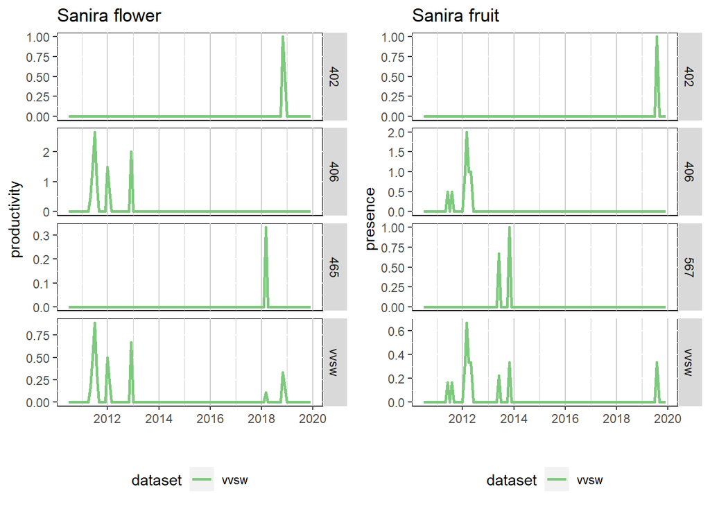

```r
# get a random species
subsp <- sample(phen_merged$species, 1)
# subset out sample species flowering data
subdf <- phen_merged[which(phen_merged$species == subsp),]
subdf <- arrange(subdf, Date) # arrange chronologically

# plot time series of sample species flower productivity
fl_plot <- ggplot(subdf %>% filter(stage == 'flower'), aes(x=Date,y=productivity)) +
                  geom_line(aes(color = dataset), size = 1) + # color lines by the community that plant is a part of
                  ylab("productivity") + # assign y label
                  xlab("") + # assign x label
                  theme(legend.position="bottom", # position legend to the bottom of the graph
                        panel.background = element_rect(fill = 'white',colour = 'black'), # assign panel aesthetics
                        panel.grid.major.x =  element_line(colour = "grey80"), # assign major grid aesthetics
                        panel.grid.minor.x = element_line(colour = "grey80")) + # assign minor grid aesthetics
                  facet_wrap(~Tag, ncol=1, # create graph for each individual/species
                             strip.position = 'right',
                             scales = 'free_y') +
                  scale_color_brewer(palette = 'Accent') + # assign color aesthetic
                  ggtitle(paste(subsp, 'flower')) # assign title as [species name] flower

# plot time series of sample species fruit productivity
fr_plot <- ggplot(subdf %>% filter(stage == 'fruit'),aes(x=Date,y=productivity))+
                geom_line(aes(color = dataset), size = 1) +  # color lines by the community that plant is a part of
                ylab("presence") + # assign y label
                xlab("") + # assign x label
                theme(legend.position="bottom") +  # position legend to the bottom of the graph
                theme(panel.background = element_rect(fill = 'white',colour = 'black'), # assign panel aesthetics
                panel.grid.major.x =  element_line(colour = "grey80"), # assign major grid aesthetics
                panel.grid.minor.x = element_line(colour = "grey80")) + # assign minor grid aesthetics
                facet_wrap(~Tag,ncol=1,
                           strip.position = 'right',
                           scales = 'free_y') + # create graph for each individual/species
                scale_color_brewer(palette = 'Accent') + # assign color aesthetic
                ggtitle(paste(subsp, 'fruit')) # assign title as [species name] fruit

# plot sample flower and fruit productivity side by side
grid.arrange(fl_plot,
             fr_plot,
             nrow = 1,
             ncol = 2)
```

Function to calculate phenological cycle duration, interval and length for each individual and species

```r
cycle_quant <- function(cycle_component, ID){
  # cycle_component: run length encoder that calculates number
  # consecutive flowering/fruiting months (duration) and non-flowering/non-fruiting months (intervals)
  # ID: unique individual or species identifier
  # get number of intervals and duration
  # extract out whether the cycle length pertains to a flowering interval (values = 0) or duration (values = 1)
  cycle_values <- cycle_component$values
  # extract out the number of months for each flowering duration/interval
  cycle_lengths <- cycle_component$lengths
  # get number of cycle components (intervals + durations counts)
  num_cycles <- length(cycle_component$lengths)
  # get number of flowering/fruiting durations (as indicated by a value of 1)
  on_months <- sum(cycle_component$lengths[which(cycle_component$values == 1)])
  # get number of flowering/fruiting intervals (as indicated by a value of 0)
  off_months <- sum(cycle_component$lengths[which(cycle_component$values == 0)])

  # summarize cycle characteristics
  if (num_cycles < 2) { # if there is less than 2 cycle components, then we don't have a full cycle (interval & duration components)
    # so set entry to NA
    cycle_df <- data.frame(ID = ID,
                           episodes = 0,
                           cycle_num = 0,
                           total_duration = on_months,
                           total_interval = off_months,
                           cycle_duration = on_months,
                           cycle_interval = off_months,
                           start = ifelse(cycle_values == 0, 'off','on')) # start "on" indicates that a record
                                       # started with an active flowering or fruiting period
                                       # and "off indicates that a record started with a
                                       # nonflowering or nonfruiting period
    print('cycle length too short to quantify')
  }
  else if (num_cycles == 2){ # there are only 2 components
    cycle_df <- data.frame(ID = ID,
                           episodes = 1,
                           cycle_num = 1,
                           total_duration = on_months,
                           total_interval = off_months,
                           cycle_duration = on_months,
                           cycle_interval = off_months,
                           start = ifelse(cycle_values == 0, 'off','on')) # start "on" indicates that a record
                                       # started with an active flowering or fruiting period
                                       # and "off indicates that a record started with a
                                       # nonflowering or nonfruiting period
  }
  else { # if there is more than 2 cycle components
    if (cycle_values[1] == 0) { # if the first entry is a nonfruiting or nonflowering period
      # drop the first records to ensure the sequence starts
      # with an active fruiting or flowering period
      cycle_lengths <- cycle_lengths[2:length(cycle_lengths)]
      cycle_values <- cycle_values[2:length(cycle_values)]
      print('drop first nonfruiting, nonflowering record')
      if (length(cycle_lengths) < 2) { # if the number of periods is fewer than two
        # don't have full cycle, set to NA
        cycle_df <- data.frame(ID = ID,
                               episodes = 0,
                               cycle_num = 0,
                               total_duration = on_months,
                               total_interval = off_months,
                               cycle_duration = on_months,
                               cycle_interval = off_months,
                               start = 'off')
        print('cycle length too short to quantify')
      }
      else{
        if (length(cycle_values) %% 2 == 1){ # if the number of periods is odd
          # drop last record to ensure full cycles
          cycle_lengths <- cycle_lengths[1:(length(cycle_lengths)-1)]
          cycle_values <- cycle_values[1:(length(cycle_values)-1)]
          print('number of periods was odd so dropped last period')
          cycle_number <- sum(cycle_values) # get number of cycles
          cycle_df <- data.frame(ID =ID,
                               episodes = cycle_number,
                               cycle_num = 1:cycle_number, # assign cycle ID
                               total_duration = on_months,
                               total_interval = off_months,
                               # get each cycle duration
                               cycle_duration = cycle_lengths[seq(1,length(cycle_lengths),2)],
                               # get each cycle interval
                               cycle_interval = cycle_lengths[seq(2,length(cycle_lengths),2)],
                               start ='off')
        }
        else {
          cycle_number <- sum(cycle_values) # get number of cycles
          cycle_df <- data.frame(ID =ID,
                               episodes = cycle_number,
                               cycle_num = 1:cycle_number, # assign cycle ID
                               total_duration = on_months,
                               total_interval = off_months,
                               # get each cycle duration
                               cycle_duration = cycle_lengths[seq(1,length(cycle_lengths),2)],
                               # get each cycle interval
                               cycle_interval = cycle_lengths[seq(2,length(cycle_lengths),2)],
                               start ='off')
        }
        print('quantified cycle')
      }
    }

    else { # else if the first entry is a fruiting or flowering period
      if (length(cycle_values) %% 2 == 1) { # if the number of periods is odd
          # drop last record to ensure full cycles
          cycle_lengths <- cycle_lengths[1:(length(cycle_lengths)-1)]
          print(length(cycle_lengths))
          cycle_values <- cycle_values[1:(length(cycle_values)-1)]
          print('number of periods was odd so dropped last period')
          cycle_number <- sum(cycle_values) # get number of cycles
          cycle_df <- data.frame(ID = ID,
                             episodes = cycle_number,
                             cycle_num = 1:cycle_number, # assign cycle ID
                             total_duration = on_months,
                             total_interval = off_months,
                             # get each cycle duration
                             cycle_duration = cycle_lengths[seq(1,length(cycle_lengths),2)],
                             # get each cycle interval
                             cycle_interval = cycle_lengths[seq(2,length(cycle_lengths),2)],
                             start ='on')
      }
      else{
        cycle_number <- sum(cycle_values) # get number of cycles
        cycle_df <- data.frame(ID = ID,
                             episodes = cycle_number,
                             cycle_num = 1:cycle_number, # assign cycle ID
                             total_duration = on_months,
                             total_interval = off_months,
                             # get each cycle duration
                             cycle_duration = cycle_lengths[seq(1,length(cycle_lengths),2)],
                             # get each cycle interval
                             cycle_interval = cycle_lengths[seq(2,length(cycle_lengths),2)],
                             start ='on')
      }
      print('quantified cycle')
    }
  }
  cycle_df$cycle_length <- cycle_df$cycle_duration + cycle_df$cycle_interval # calculate cycle length
  return(cycle_df) # output the table
}
```

```r
# calculate cycle characteristics in parallel for each individual and species in parallel
cycle_df <- foreach(i = unique(phen_merged$ID), .combine = 'rbind') %dopar%{
  # subset the phenology records for an individual/species
  # data should already be chronological
  subdf <- phen_merged[which(phen_merged$ID == i),]
  # calculate periods of flowering or fruiting (duration) and nonflowering or nonfruiting (intervals)
  cycle_component <- rle(subdf$presence)
  # characterize each flowering/fruiting cycle
  sub_cycle <- cycle_quant(cycle_component, i)
  return(sub_cycle)
}

head(cycle_df)
```

```
##                  ID episodes cycle_num total_duration total_interval
## 1 Ambora_174_flower       12         1             22             92
## 2 Ambora_174_flower       12         2             22             92
## 3 Ambora_174_flower       12         3             22             92
## 4 Ambora_174_flower       12         4             22             92
## 5 Ambora_174_flower       12         5             22             92
## 6 Ambora_174_flower       12         6             22             92
##   cycle_duration cycle_interval start cycle_length
## 1              2             11   off           13
## 2              1              6   off            7
## 3              2             14   off           16
## 4              1              7   off            8
## 5              2              1   off            3
## 6              1              2   off            3
```

Assign cycle categorization based on the classification scheme in  
Newstrom LE, Frankie GW, Baker HG (1994a) A new classification for plant phenology based on flowering patterns in lowland tropical rain forest trees at La Selva, Costa Rica. Biotropica 26:141–159. https://doi.org/10.2307/2388804\  
Cycle classification definitions:  
Annual flowering and fruiting cycles occur once per year  
Sub-annual cycles occur multiple times per year  
Supra-annual cycles occur less than once a year  
Continual cycles are patterns of constant flowering or fruiting with no or infrequent, brief interruptions

```r
# function to categorize cycles
# if cycle length is less than 11 months assign as sub-annual
cycle_df$cycle_category <- ifelse(cycle_df$cycle_length < 11, 'sub-annual',
                                  # if cycle length is between 11-13 months assign as annual
                                  ifelse(between(cycle_df$cycle_length,11,13),'annual',
                                         # if cycle interval is greater than 2 months,
                                         # then assign as supra-annual
                                         ifelse(cycle_df$cycle_interval > 2, 'supra-annual',
                                                # otherwise categorize as continual
                                                ifelse(cycle_df$cycle_interval <=2, 'continual',NA))))

# for individuals/species that exhibited only one cycle, assign as either supra-annual or continual across the 9 years phenology was collected
# leave the cycle categories of individuals/species with more than one cycle alone
cycle_df$cycle_category <- ifelse(cycle_df$episodes != 1, cycle_df$cycle_category,
                                  # if the cycle duration was shorter than the interval duration
                                  # then asasign as supra-annual, otherwise assign as continual
                                   ifelse(cycle_df$total_duration < cycle_df$total_interval,
                                          'supra-annual','continual'))

# get rid of leading and tailing sub-annual and annual cycles since we cannot tell how much long these cycles lasted
# leading = first cycle for an individual/species
# tailing = last cycle for an individual/species
cycle_df$cycle_category <- ifelse(cycle_df$cycle_num == 1 & # if it is a leading cycle
                                    # and the cycle is categorized as a sub-annual and annual
                                    cycle_df$cycle_category %in% c('sub-annual','annual') &
                                    # and the cycle starts as an active flowering/fruiting period
                                    # then reassign to NA, otherwise keep as is
                                    cycle_df$start == 'on', NA, cycle_df$cycle_category)

cycle_df$cycle_category <- ifelse(cycle_df$cycle_num == cycle_df$episodes & # if it is a tailing cycle
                                    # and the cycle is categorized as a sub-annual and annual
                                    cycle_df$cycle_category %in% c('sub-annual','annual') &
                                    # and the cycle ends as an active flowering/fruiting period
                                    # then reassign to NA, otherwise keep as is
                                    cycle_df$start == 'off',NA, cycle_df$cycle_category)

# add in identifying information for each cycle based on its ID
cycle_df <- merge(cycle_df, distinct(phen_merged[,c('ID','species','Tag','stage','dataset')]),
                  by = 'ID',
                  all.x = T,
                  all.y = F)

# assign the scale of analysis (species or individual)
# Tags = sssw or vvsw indicate species
cycle_df$scale <- ifelse(cycle_df$Tag %in% c('sssw','vvsw'), 'species', 'individual')

# view subsample of cycle data
head(cycle_df[which(is.na(cycle_df$cycle_category)),])
```

```
##                   ID episodes cycle_num total_duration total_interval
## 12 Ambora_174_flower       12        12             22             92
## 23  Ambora_174_fruit       11        11             29             85
## 34 Ambora_226_flower       11        11             25             89
## 42  Ambora_226_fruit        8         8             26             88
## 52 Ambora_385_flower       10        10             20             94
## 63  Ambora_385_fruit       11        11             32             82
##    cycle_duration cycle_interval start cycle_length cycle_category species Tag
## 12              2              5   off            7           <NA>  Ambora 174
## 23              6              6   off           12           <NA>  Ambora 174
## 34              1              6   off            7           <NA>  Ambora 226
## 42              4              4   off            8           <NA>  Ambora 226
## 52              2              5   off            7           <NA>  Ambora 385
## 63              7              1   off            8           <NA>  Ambora 385
##     stage dataset      scale
## 12 flower    sssw individual
## 23  fruit    sssw individual
## 34 flower    sssw individual
## 42  fruit    sssw individual
## 52 flower    sssw individual
## 63  fruit    sssw individual
```

```r
# get number of cycles in each category for individuals
cycle_df %>% filter(scale != 'species') %>% group_by(cycle_category,dataset) %>% count()
```

```
## # A tibble: 10 x 3
## # Groups:   cycle_category, dataset [10]
##    cycle_category dataset     n
##    <chr>          <chr>   <int>
##  1 annual         sssw      232
##  2 annual         vvsw      193
##  3 continual      sssw        6
##  4 continual      vvsw        6
##  5 sub-annual     sssw     1071
##  6 sub-annual     vvsw      315
##  7 supra-annual   sssw      372
##  8 supra-annual   vvsw      367
##  9 <NA>           sssw      104
## 10 <NA>           vvsw       91
```

```r
# get number of cycles in each category for species
cycle_df %>% filter(scale == 'species') %>% group_by(cycle_category,dataset) %>% count()
```

```
## # A tibble: 10 x 3
## # Groups:   cycle_category, dataset [10]
##    cycle_category dataset     n
##    <chr>          <chr>   <int>
##  1 annual         sssw       29
##  2 annual         vvsw       13
##  3 continual      sssw        5
##  4 continual      vvsw        3
##  5 sub-annual     sssw      141
##  6 sub-annual     vvsw       85
##  7 supra-annual   sssw       28
##  8 supra-annual   vvsw       28
##  9 <NA>           sssw       15
## 10 <NA>           vvsw       11
```

```r
write.csv(cycle_df, 'phen_cycle_characteristics.csv')

head(cycle_df)
```

```
##                  ID episodes cycle_num total_duration total_interval
## 1 Ambora_174_flower       12         1             22             92
## 2 Ambora_174_flower       12         2             22             92
## 3 Ambora_174_flower       12         3             22             92
## 4 Ambora_174_flower       12         4             22             92
## 5 Ambora_174_flower       12         5             22             92
## 6 Ambora_174_flower       12         6             22             92
##   cycle_duration cycle_interval start cycle_length cycle_category species Tag
## 1              2             11   off           13         annual  Ambora 174
## 2              1              6   off            7     sub-annual  Ambora 174
## 3              2             14   off           16   supra-annual  Ambora 174
## 4              1              7   off            8     sub-annual  Ambora 174
## 5              2              1   off            3     sub-annual  Ambora 174
## 6              1              2   off            3     sub-annual  Ambora 174
##    stage dataset      scale
## 1 flower    sssw individual
## 2 flower    sssw individual
## 3 flower    sssw individual
## 4 flower    sssw individual
## 5 flower    sssw individual
## 6 flower    sssw individual
```

Summarize the cycle characteristics to the individual/species

```r
# create vector of cycle names
cycle_names <- c('continual','sub-annual','annual','supra-annual')

# get rid of cycles for individuals or species that could not be characterized due to too few cycles
cycle_df <- cycle_df[which(!is.na(cycle_df$cycle_category)),]

# get summary statistics for each individual and species
cycle_summary <- cycle_df %>% group_by(ID,
                                       species,
                                       Tag,
                                       dataset,
                                       stage,
                                       scale,
                                       episodes,
                                       total_duration,
                                       total_interval) %>%
                              summarise(n = n(), # number of cycles
                                        continual = length(which(cycle_category == 'continual')), # number of continual cycles
                                        sub_annual = length(which(cycle_category == 'sub-annual')), # number of sub-annual cycles
                                        annual = length(which(cycle_category == 'annual')), # number of annual cycles
                                        supra_annual = length(which(cycle_category == 'supra-annual')), # number of supra-annual cycles
                                        length_min = min(cycle_length, na.rm =T), # minimum cycle length
                                        length_max = max(cycle_length, na.rm =T),  # maximum cycle length
                                        length_mean = mean(cycle_length, na.rm =T), # mean cycle length
                                        length_sd = sd(cycle_length,na.rm =T), # standard deviation in cycle length
                                        length_median = median(cycle_length,na.rm =T), # median in cycle length
                                        length_mad = mad(cycle_length,na.rm =T), # median absolute deviation in cycle length
                                        duration_min = min(cycle_duration, na.rm =T), # minimum cycle duration
                                        duration_max = max(cycle_duration, na.rm =T), # maximum cycle duration
                                        duration_mean = mean(cycle_duration, na.rm =T), # mean cycle duration
                                        duration_sd = sd(cycle_duration,na.rm =T), # standard deviation in cycle duration
                                        duration_median = median(cycle_duration,na.rm =T), # median cycle duration
                                        duration_mad = mad(cycle_duration,na.rm =T), # median absolute deviation in cycle duration
                                        interval_min = min(cycle_interval, na.rm =T), # minimum cycle interval
                                        interval_max = max(cycle_interval, na.rm =T), # maximum cycle interval
                                        interval_mean = mean(cycle_interval, na.rm =T), # mean cycle interval
                                        interval_sd = sd(cycle_interval,na.rm =T), # standard deviation in cycle interval
                                        interval_median = median(cycle_interval,na.rm =T), # median cycle interval
                                        interval_mad = mad(cycle_interval,na.rm =T)) %>% # median absolute deviation in cycle interval
                              # get dominant cycle frequency and proportion
                              # dominant cycle is the cycle class that was most exhibited by the plant
                              # frequency of the dominant cycle
                              mutate(dom_freq = max(c(continual, sub_annual,annual, supra_annual), na.rm = T),
                                     # proportion of the dominant cycle
                                     dom_prop = max(c(continual, sub_annual,annual, supra_annual), na.rm = T)/n(),
                                     # names of dominant cycle(s)
                                     dom_cycles = paste0(cycle_names[which(c(continual, sub_annual,annual,                                                                                      supra_annual)==dom_freq)], collapse ='/'))

# merge in plant names
cycle_summary <- merge(plant_names, cycle_summary,
                       by.x = 'Species',
                       by.y = 'species',
                       all.x = F,
                       all.y = T)

# flag plants without a dominant cycle
cycle_summary$cycle_category <- sapply(1:nrow(cycle_summary),
                                       function(x) grepl('/', cycle_summary$dom_cycle[x]))

# reassign plants without a dominant cycle to "no dominance'
cycle_summary$cycle_category <- ifelse(cycle_summary$cycle_category == 'FALSE',
                                       cycle_summary$dom_cycle, 'no dominance')

# convert to factor and specify level order
cycle_summary$cycle_category <- factor(cycle_summary$cycle_category,
                                       levels = c('continual','sub-annual','annual','supra-annual','no dominance'))


# get column names
colnames(cycle_summary)
```

```
##  [1] "Species"         "Latin"           "multispecies"    "ID"
##  [5] "Tag"             "dataset"         "stage"           "scale"
##  [9] "episodes"        "total_duration"  "total_interval"  "n"
## [13] "continual"       "sub_annual"      "annual"          "supra_annual"
## [17] "length_min"      "length_max"      "length_mean"     "length_sd"
## [21] "length_median"   "length_mad"      "duration_min"    "duration_max"
## [25] "duration_mean"   "duration_sd"     "duration_median" "duration_mad"
## [29] "interval_min"    "interval_max"    "interval_mean"   "interval_sd"
## [33] "interval_median" "interval_mad"    "dom_freq"        "dom_prop"
## [37] "dom_cycles"      "cycle_category"
```

```r
# reorder table columns
cycle_summary <- cycle_summary[,c(4,1:3,5:8,12,38,37,35:36,13:16,9:11,17:34)]
head(cycle_summary)
```

```
##                  ID Species                   Latin multispecies Tag dataset
## 1 Ambora_174_flower  Ambora Tambourissa thouvenotii        FALSE 174    sssw
## 2  Ambora_226_fruit  Ambora Tambourissa thouvenotii        FALSE 226    sssw
## 3 Ambora_385_flower  Ambora Tambourissa thouvenotii        FALSE 385    sssw
## 4  Ambora_174_fruit  Ambora Tambourissa thouvenotii        FALSE 174    sssw
## 5 Ambora_226_flower  Ambora Tambourissa thouvenotii        FALSE 226    sssw
## 6  Ambora_395_fruit  Ambora Tambourissa thouvenotii        FALSE 395    vvsw
##    stage      scale  n cycle_category   dom_cycles dom_freq dom_prop continual
## 1 flower individual 11     sub-annual   sub-annual        7        7         0
## 2  fruit individual  7     sub-annual   sub-annual        4        4         0
## 3 flower individual  9     sub-annual   sub-annual        6        6         0
## 4  fruit individual 10     sub-annual   sub-annual        8        8         0
## 5 flower individual 10     sub-annual   sub-annual        6        6         0
## 6  fruit individual  5   supra-annual supra-annual        4        4         0
##   sub_annual annual supra_annual episodes total_duration total_interval
```

[output cut: 34 more lines]

```r
# get the number of dominant cycles in each category for individuals
cycle_summary %>% filter(scale == 'individual') %>%
                  group_by(stage, dataset, cycle_category) %>%
                  count()
```

```
## # A tibble: 16 x 4
## # Groups:   stage, dataset, cycle_category [16]
##    stage  dataset cycle_category     n
##    <chr>  <chr>   <fct>          <int>
##  1 flower sssw    sub-annual        62
##  2 flower sssw    annual             1
##  3 flower sssw    supra-annual      30
##  4 flower sssw    no dominance      10
##  5 flower vvsw    sub-annual        27
##  6 flower vvsw    annual            15
##  7 flower vvsw    supra-annual      49
##  8 flower vvsw    no dominance      10
##  9 fruit  sssw    sub-annual        61
## 10 fruit  sssw    supra-annual      31
## 11 fruit  sssw    no dominance      10
## 12 fruit  vvsw    continual          1
## 13 fruit  vvsw    sub-annual        19
## 14 fruit  vvsw    annual             6
## 15 fruit  vvsw    supra-annual      51
## 16 fruit  vvsw    no dominance      16
```

```r
# get the number of dominant cycles in each category for species
cycle_summary %>% filter(scale == 'species') %>%
                  group_by(stage, dataset, cycle_category) %>%
                  count()
```

```
## # A tibble: 11 x 4
## # Groups:   stage, dataset, cycle_category [11]
##    stage  dataset cycle_category     n
##    <chr>  <chr>   <fct>          <int>
##  1 flower sssw    sub-annual         9
##  2 flower sssw    supra-annual       1
##  3 flower vvsw    sub-annual         4
##  4 flower vvsw    no dominance       4
##  5 fruit  sssw    continual          1
##  6 fruit  sssw    sub-annual         8
##  7 fruit  sssw    no dominance       1
##  8 fruit  vvsw    continual          1
##  9 fruit  vvsw    sub-annual         2
## 10 fruit  vvsw    supra-annual       2
## 11 fruit  vvsw    no dominance       3
```

Get a sense of the individual and species sample size before dropping cycles with too few cycles

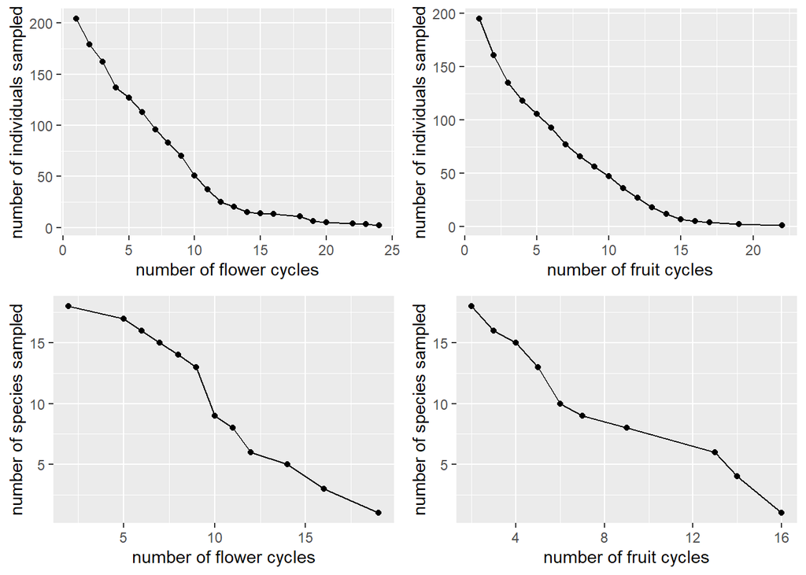

```r
# summarize the sample size of the number of flowering cycles per species during the study period
cycle_species_sample <- cycle_summary %>% filter(stage == 'flower' & scale == 'species') %>%
                                          group_by(n) %>%
                                          summarise(counts = n()) %>%
                                          arrange(desc(n))

# get cumulative sample sizes
cycle_species_sample$samples <- cumsum(cycle_species_sample$counts)

# plot cumulative sample size
fls_plot <- ggplot(cycle_species_sample, aes(x = n, y = samples)) +
                geom_point() +
                geom_line() +
                labs(x = 'number of flower cycles', y = 'number of species sampled')

# summarize the sample size of the number of fruiting cycles per species during the study period
cycle_species_sample <- cycle_summary %>% filter(stage == 'fruit' & scale == 'species') %>%
                                          group_by(n) %>%
                                          summarise(counts = n()) %>%
                                          arrange(desc(n))

# get cumulative sample sizes
cycle_species_sample$samples <- cumsum(cycle_species_sample$counts)

frs_plot <- ggplot(cycle_species_sample, aes(x = n, y = samples)) +
                geom_point() +
                geom_line() +
                labs(x = 'number of fruit cycles', y = 'number of species sampled')

# summarize the sample size of the number of flowering cycles per individuals during the study period
cycle_individual_sample <- cycle_summary %>% filter(stage == 'flower' & scale == 'individual') %>%
                                             group_by(n) %>%
                                             summarise(counts = n()) %>%
                                             arrange(desc(n))

# cumulative sample size
cycle_individual_sample$samples <- cumsum(cycle_individual_sample$counts)

# plot cumulative sample size
fli_plot <- ggplot(cycle_individual_sample, aes(x = n, y = samples)) +
                geom_point() +
                geom_line() +
                labs(x = 'number of flower cycles', y = 'number of individuals sampled')

# summarize the sample size of the number of fruiting cycles per individuals during the study period
cycle_individual_sample <- cycle_summary %>% filter(stage == 'fruit' & scale =='individual') %>%
                                             group_by(n) %>%
                                             summarise(counts = n()) %>%
                                             arrange(desc(n))

# cumulative sample size
cycle_individual_sample$samples <- cumsum(cycle_individual_sample$counts)

# plot cumulative sample size
fri_plot <- ggplot(cycle_individual_sample, aes(x = n, y = samples)) +
                geom_point() +
                geom_line() +
                labs(x = 'number of fruit cycles', y = 'number of individuals sampled')


# plot sample sizes
grid.arrange(fli_plot, fri_plot, fls_plot, frs_plot, nrow =2, ncol = 2)
```

```r
# # # restrict analyses to individuals and species that underwent at least 3 cycles
# cycle_summary3 <- cycle_summary[which(cycle_summary$n > 2),]
# write.csv(cycle_summary, 'phen_cycle_character_summary.csv') # save table
#
# # correspondingly subset the cycle characteristic table with the plants that have at least 3 cycles
# cycle_df3 <- cycle_df[which(cycle_df$ID %in% cycle_summary3$ID),]
```

**The flowering and fruiting phenologies were characterized for how many individuals and species?**

```r
cycle_summary %>% group_by(scale, stage,dataset) %>%
                  summarise(n = length(unique(ID)),
                            taxa = length(unique(Species)))
```

```
## # A tibble: 8 x 5
## # Groups:   scale, stage [4]
##   scale      stage  dataset     n  taxa
##   <chr>      <chr>  <chr>   <int> <int>
## 1 individual flower sssw      103    37
## 2 individual flower vvsw      101    39
## 3 individual fruit  sssw      102    37
## 4 individual fruit  vvsw       93    38
## 5 species    flower sssw       10    10
## 6 species    flower vvsw        8     8
## 7 species    fruit  sssw       10    10
## 8 species    fruit  vvsw        8     8
```

Visualize random sample of results

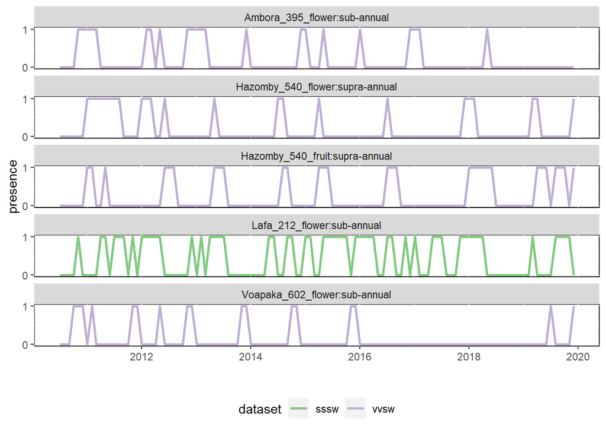

```r
# draw five random plants
ids <- sample(cycle_summary$ID, 5, replace = F)

# subset out phenology data of the sample 5 plants
subdf <- phen_merged[which(phen_merged$ID %in% ids),]
# subset the cycle summary of these sample plants
subdf <- merge(subdf, cycle_summary[,c('ID','dom_cycles')],
               by = 'ID',
               all.x =T,
               all.y = F)

# chronologically order
subdf <- arrange(subdf, ID, Date)

# plot time series of absence/presence of these sample plants
ggplot(subdf,aes(x=Date,y=presence)) +
                geom_line(aes(color = dataset), size = 1) + # line graph to plot phenology time series
                ylab("presence") + # y axis label
                xlab("") + # remove x axis label
                theme(legend.position="bottom") +
                theme(panel.background = element_rect(fill = 'white',colour = 'black')) +  # set panel aesthetics
                scale_y_continuous(breaks = c(0,1)) +
                facet_wrap(~paste(ID,dom_cycles, sep = ":"), # plot per sample plant
                           ncol=1,
                           strip.position = 'top',
                           scales = 'free_y') +
                scale_color_brewer(palette = 'Accent') # select color aesthetic
```

Visualize distribution of dominant cycles at community level using grouped bar plot

```r
# summarize dominant cycles
dompop_summary <- cycle_summary %>% group_by(dataset, stage, scale,cycle_category) %>%
                                    count(cycle_category,.drop = FALSE)

# tally dominant cycles and get Goodman Estimation of confidence of multinomial proportions
# create empty list to store a table each for
# flowering individual, fruiting individual, flowering species, fruiting species per forest community
mci_list <- list()

# generate dominant cycle tables for each forest
for (i in c('sssw','vvsw')){
  # subset data for the flowering individuala and calculate 95% CI based on Goodman Estimation
  flindi <- MultinomCI(dompop_summary$n[which(dompop_summary$dataset == i &
                                              dompop_summary$stage == 'flower' &
                                              dompop_summary$scale == 'individual')],
                       0.95, 'two.sided', 'goodman') # generate dominany cycle table for flowering individual
  # subset data for the fruiting individuala and calculate 95% CI based on Goodman Estimation
  frindi <- MultinomCI(dompop_summary$n[which(dompop_summary$dataset == i &
                                              dompop_summary$stage == 'fruit' &
                                              dompop_summary$scale == 'individual')],
                       0.95, 'two.sided', 'goodman') # generate dominany cycle table for fruiting individual
  # subset data for the flowering species and calculate 95% CI based on Goodman Estimation
  flsp <- MultinomCI(dompop_summary$n[which(dompop_summary$dataset == i &
                                              dompop_summary$stage == 'flower' &
                                              dompop_summary$scale == 'species')],
                     0.95, 'two.sided', 'goodman') # generate dominany cycle table for flowering species
  # subset data for the fruiting individuala and calculate 95% CI based on Goodman Estimation
  frsp <- MultinomCI(dompop_summary$n[which(dompop_summary$dataset == i &
                                              dompop_summary$stage == 'fruit' &
                                              dompop_summary$scale == 'species')],
                     0.95, 'two.sided', 'goodman') # generate dominany cycle table for fruiting individual
  # append all CI summary tables into a list
  mci_list <- append(mci_list,list(flindi,flsp,frindi,frsp)) # append to list
}

# merge all dominant cycle tables into a single table
ml_tab <- do.call(rbind, mci_list) # merge tables

# merge multinomial estimates to summary table
dompop_summary <- cbind(as.data.frame(dompop_summary), as.data.frame(ml_tab))

# print summary table
print(dompop_summary)
```

```
##    dataset  stage      scale cycle_category  n         est      lwr.ci
## 1     sssw flower individual      continual  0 0.000000000 0.000000000
## 2     sssw flower individual     sub-annual 62 0.601941748 0.475195992
## 3     sssw flower individual         annual  1 0.009708738 0.001140887
## 4     sssw flower individual   supra-annual 30 0.291262136 0.191412377
## 5     sssw flower individual   no dominance 10 0.097087379 0.044661652
## 6     sssw flower    species      continual  0 0.000000000 0.000000000
## 7     sssw flower    species     sub-annual  9 0.900000000 0.492768229
## 8     sssw flower    species         annual  0 0.000000000 0.000000000
## 9     sssw flower    species   supra-annual  1 0.100000000 0.011851503
## 10    sssw flower    species   no dominance  0 0.000000000 0.000000000
## 11    sssw  fruit individual      continual  0 0.000000000 0.000000000
## 12    sssw  fruit individual     sub-annual 61 0.598039216 0.470735277
## 13    sssw  fruit individual         annual  0 0.000000000 0.000000000
## 14    sssw  fruit individual   supra-annual 31 0.303921569 0.201598944
```

[output cut: 67 more lines]

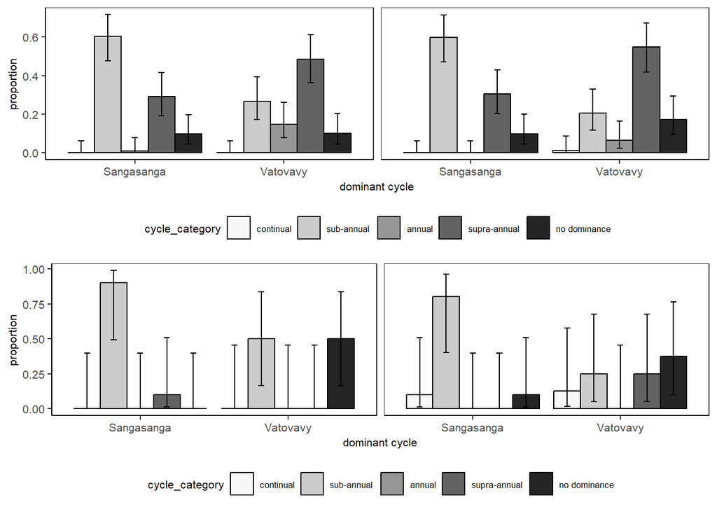

```r
# save table
write.csv(dompop_summary, 'dom_pop_summary_commphen.csv')

# relabel the dataset column with the full forest name for visualization purposes
dompop_summary$dataset <- ifelse(dompop_summary$dataset =='sssw', 'Sangasanga','Vatovavy')

# generate bar plot of dominant cycles with confidence intervals for individuals
indi_plot <- ggplot(dompop_summary %>% filter(scale == 'individual'),  # subset out individual data
                  aes(x = dataset, y = est, fill = cycle_category)) +
                  geom_bar(stat = 'identity',
                           position = 'dodge',
                           color = 'black') + # side by side bar plots
                  geom_errorbar(aes(ymin = lwr.ci, ymax = upr.ci), # with confidence intervals
                                position = position_dodge(width = 0.9),
                                colour = 'black',
                                width = 0.2) +
                  theme_bw() + # set plot theme
                  theme(axis.line = element_line(color='black'),
                        text = element_text(size = 8),
                        axis.text = element_text(size = 8),
                        plot.background = element_blank(),
                        panel.grid.major = element_blank(),
                        panel.grid.minor = element_blank(),
                        strip.text.x = element_blank(),
                        legend.position = 'bottom') +
                scale_fill_brewer(palette='Greys') + # select fill aesthetics
                labs(y = 'proportion', x = 'dominant cycle') + # assign axis labels
            facet_wrap(~stage, # plot per phenology stage
                       nrow = 1,
                       ncol = 2)

# generate barplot of dominant cycles with confidence intervals for species
sp_plot <- ggplot(dompop_summary %>% filter(scale == 'species'), # subset out species data
                  aes(x = dataset, y = est, fill = cycle_category)) +
            geom_bar(stat = 'identity',
                     position = 'dodge',
                     color = 'black') + # side by side barplots
            geom_errorbar(aes(ymin = lwr.ci, ymax = upr.ci), # with confidence intervals
                          position = position_dodge(width = 0.9),
                          colour = 'black',
                          width = 0.2) +
            theme_bw() + # set plot theme
            theme(axis.line = element_line(color='black'), # further modify theme aesthetics
                  text = element_text(size = 8),
                  axis.text = element_text(size = 8),
                  plot.background = element_blank(),
                  panel.grid.major = element_blank(),
                  panel.grid.minor = element_blank(),
                  strip.text.x = element_blank(),
                  legend.position = 'bottom') +
            scale_fill_brewer(palette='Greys') + # select fill aesthetics
                labs(y = 'proportion', x = 'dominant cycle') + # assign axis labels
            facet_wrap(~stage, # plot per phenology stage
                       nrow = 1,
                       ncol = 2)

# arrange figure
fig1 <- plot_grid(indi_plot, sp_plot,ncol = 1, nrow = 2)

fig1
```

```r
# save figure
ggsave(file = 'fig1.jpeg',
       plot = fig1,
       width = 5.1,
       height = 4,
       units = 'in')
```

Visualize distribution of dominant cycles at community level using stacked barplot

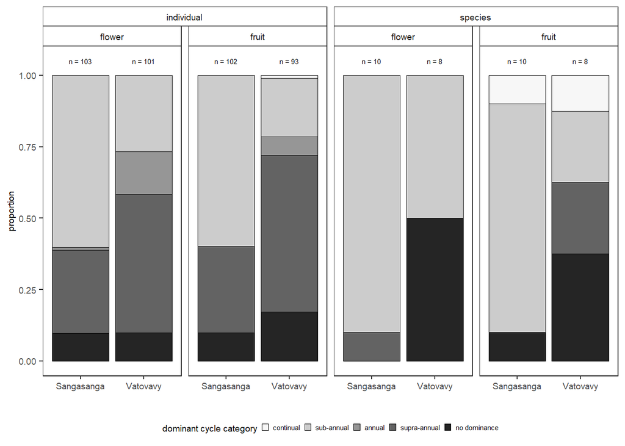

```r
# To add sample size to the stacked bar plots
# get number of cycles counted per forest community (dataset), stage, scale (i.e., sample size)
dompop_n <- dompop_summary %>% group_by(dataset, stage, scale) %>%
                               summarize(total_n = sum(n))
# convert from tibble to dataframe
dompop_n <- as.data.frame(dompop_n)
dompop_n$total_n <- sapply(1:nrow(dompop_n), function(x) paste0(c('n = ', dompop_n$total_n[x]), collapse='')) # add "n = " into sample size

# assign one of the cycles to cycle category column to align with the dominant cycle category column
dompop_n$cycle_category <- 'annual' # annual was selected arbitrarily, any other cycle category could have been used

# generate barplot of dominant cycles with confidence intervals for individuals
dom_plot <- ggplot(dompop_summary,  # subset out individual data
                  aes(x = dataset, y = est, fill = cycle_category)) +
                  geom_col(color = 'black',position = 'fill', size = 0.2) + # create stacked bar plot
                  geom_text(data = dompop_n,
                            aes(x = dataset, y = 1.05, label = total_n),
                            size = 2) +
                  theme_bw() + # set plot theme
                  # further modify theme aesthetics
                  theme(axis.line = element_line(color='black', size = 0.1),
                        text = element_text(size = 7),
                        axis.text = element_text(size = 7),
                        plot.background = element_blank(),
                        panel.grid.major = element_blank(),
                        panel.grid.minor = element_blank(),
                        strip.text.x = element_text(size = 7),
                        strip.background = element_rect(fill = 'white'),
                        legend.position = 'bottom',
                        legend.key.size = unit(0.2, 'cm')) + # change legend key size
                labs(y = 'proportion', x ="") + # assign axis labels
                scale_fill_brewer(name = 'dominant cycle category', palette='Greys') + # select fill aesthetics
                facet_nested(~scale + stage) # plot per flower and fruit stage

dom_plot
```

```r
# save figure
ggsave(file = 'figstacked.jpeg',
       plot = dom_plot,
       width = 5.1,
       height = 3,
       units = 'in')
```

Sangasanga: sub-annual flowering and fruiting cycles were most frequently observed across individuals and species  
Vatovavy: supra-annual flowering and fruiting cycles were most frequently observed across individuals, sub-annual and no dominance in cycles was the most frequently observed flowering cycles across species and no dominance in cycles was the most frequently observed fruiting cycles across species.